# Homework 1: A comparison of the sensitivity of Variance & Inter Quartile Range

### *Geoffrey Millard and Charitha Gunawardana*

#### CIE 600: Environmental Data Analysis: Scripting Assignment 1

#### 7th February 2017

The purpose of this R notebook is to compare the sensitivity of the variance and the inter quartile range(IQR) by manipulating a normally distributed randomly generated data set.

### Data Set:

We start by generating a random normally distributed dataset and then calculating the mean, variance and IQR of the data.

```r
knitr::opts_chunk$set(echo = TRUE)
set.seed(25) # set the starting point for the random number generator so that we will have reproducible data
data <- rnorm(50) # generate a normally distributed dataset
xbar <- mean(data) # calculate the mean
variance <- (sum((data-xbar)^2))/(length(data)-1) # calculate the variance
IQR <- boxplot(data,plot=F)$stats[4,]-boxplot(data,plot=F)$stats[2,] # find the IQR
spread <- data.frame(Distributrion=c('normal','additional','double','outlier','exp'),variance=NA,IQR=NA) # generate a data.frame to store variance and IQR for each change made to the original data set for later use
spread$variance[1] <- variance;spread$IQR[1] <- IQR
```

The variance was found to be ~0.968 while the IQR was 1.394  
Next we generate a histogram of the data with boxes indicating the variance and IQR

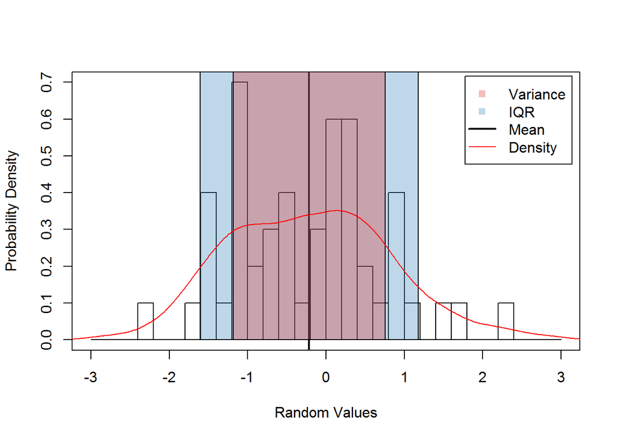

```r
hist(data,breaks=seq(-3,3,0.2),freq=F,ann=F)
box()
abline(v=xbar,lwd=2)
title(ylab='Probability Density',xlab = 'Random Values')
rect(xbar-IQR,0,xbar+IQR,0.73,col='#3182bd50')
rect(xbar-variance,-0,xbar+variance,0.73,col='#de2d2650',density=-100)

d <- density(data, adjust=1, kernel='biweight')
lines(d$x,d$y,col=2)
legend('topright',c('Variance','IQR','Mean','Density'),pch=c(15,15,NA,NA),lty=c(NA,NA,1,1),col=c('#de2d2650','#3182bd50',1,2),lwd=c(NA,NA,2,1),inset=0.015)
```

We can see from the above plot that the **IQR is greater than the variance** in this dataset.

Next we will shift the data to see how sensitive these measures of spread are.

1. Adding 5 to each point
2. Multiplying each point by 2
3. Adding outliers
4. Taking the exponential values of the data

### Lets add 5 to each data point:

The new output for the increased data looks like,

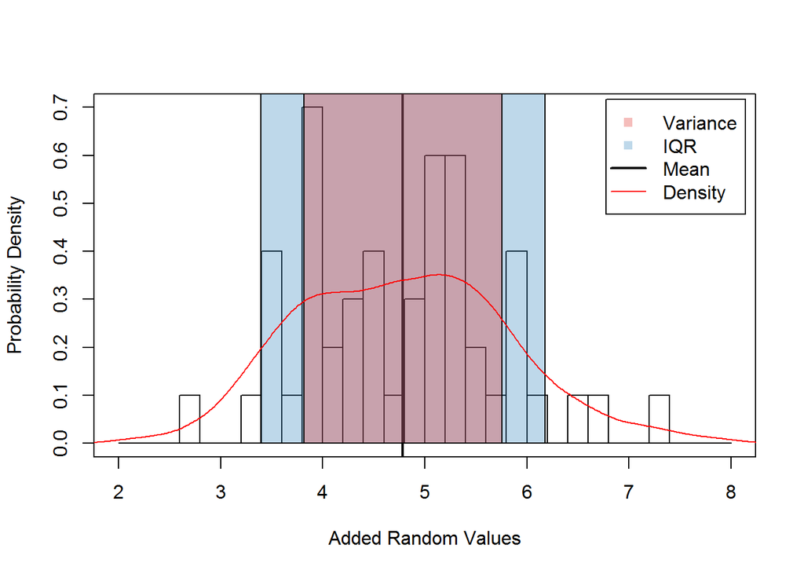

```r
adddata <- data+5 # adds 5 to each data
xbar <- mean(adddata) # calculate the mean
variance <- (sum((adddata-xbar)^2))/(length(adddata)-1) # calculate the variance
IQR <- boxplot(adddata,plot=F)$stats[4,]-boxplot(adddata,plot=F)$stats[2,] # find the IQR
spread$variance[2] <- variance;spread$IQR[2] <- IQR

hist(adddata,breaks=seq(2,8,0.2),freq=F,ann=F)
box()
abline(v=xbar,lwd=2)
title(ylab='Probability Density',xlab = 'Added Random Values')
rect(xbar-IQR,0,xbar+IQR,1.3,col='#3182bd50')
rect(xbar-variance,-0,xbar+variance,1.3,col='#de2d2650',density=-100)

d <- density(adddata, adjust=1, kernel='biweight')
lines(d$x,d$y,col=2)
legend('topright',c('Variance','IQR','Mean','Density'),pch=c(15,15,NA,NA),lty=c(NA,NA,1,1),col=c('#de2d2650','#3182bd50',1,2),lwd=c(NA,NA,2,1),inset=0.015)
```

By adding an equal value to each data point (shifting), we can see that the **varience and the IQR are the same as the original value** which was 0.968 and 1.394

### Lets multiply each data point by 2:

The new output for the multiplied data looks like,

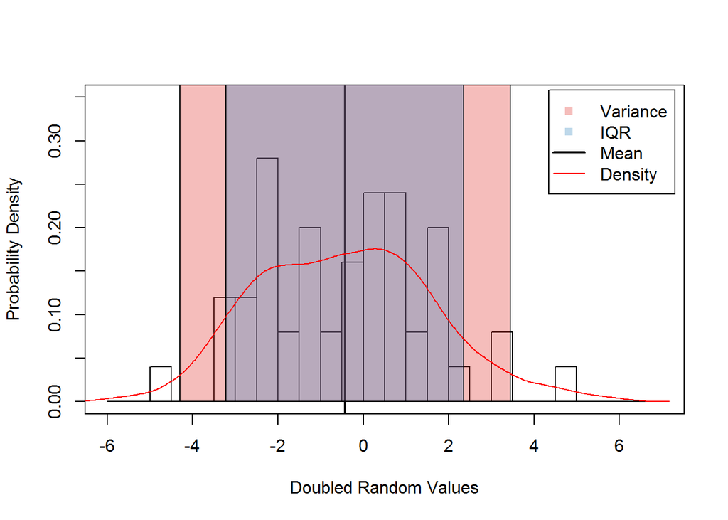

```r
dubdata <- data*2 # double the values
xbar <- mean(dubdata) # calculate the mean
variance <- (sum((dubdata-xbar)^2))/(length(dubdata)-1) # calculate the variance
IQR <- boxplot(dubdata,plot=F)$stats[4,]-boxplot(dubdata,plot=F)$stats[2,] # find the IQR
spread$variance[3] <- variance;spread$IQR[3] <- IQR

hist(dubdata,breaks=seq(-6,7,0.5),freq=F,ann=F,ylim=range(0,0.35))
box()
abline(v=xbar,lwd=2)
title(ylab='Probability Density',xlab = 'Doubled Random Values')
rect(xbar-variance,-0,xbar+variance,1.3,col='#de2d2650',density=-100)
rect(xbar-IQR,0,xbar+IQR,1.3,col='#3182bd50')

d <- density(dubdata, adjust=1, kernel='biweight')
lines(d$x,d$y,col=2)
legend('topright',c('Variance','IQR','Mean','Density'),pch=c(15,15,NA,NA),lty=c(NA,NA,1,1),col=c('#de2d2650','#3182bd50',1,2),lwd=c(NA,NA,2,1),inset=0.015)
```

By multiplying the data points by 2, we can see that variance has increased to 3.87 (4 times the original variance), while IQR has doubled in to 2.787

### Lets add a few outliers to the data set:

The new output for the added outliers data set looks like,

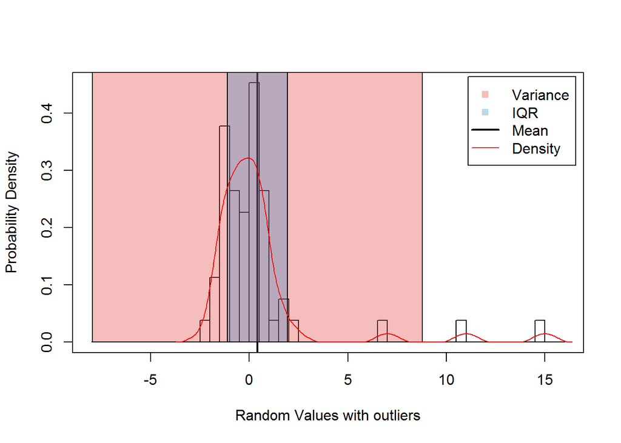

```r
outdata <- c(data,11,7,15) # add outliers
xbar <- mean(outdata) # calculate the mean
variance <- (sum((outdata-xbar)^2))/(length(outdata)-1) # calculate the variance
IQR <- boxplot(outdata,plot=F)$stats[4,]-boxplot(outdata,plot=F)$stats[2,] # find the IQR
spread$variance[4] <- variance;spread$IQR[4] <- IQR

hist(outdata,breaks=seq(-8,16,0.5),freq=F,ann=F)
box()
abline(v=xbar,lwd=2)
title(ylab='Probability Density',xlab = 'Random Values with outliers')
rect(xbar-variance,-0,xbar+variance,1.3,col='#de2d2650',density=-100)
rect(xbar-IQR,0,xbar+IQR,1.3,col='#3182bd50')

d <- density(outdata, adjust=1, kernel='biweight')
lines(d$x,d$y,col=2)
legend('topright',c('Variance','IQR','Mean','Density'),pch=c(15,15,NA,NA),lty=c(NA,NA,1,1),col=c('#de2d2650','#3182bd50',1,2),lwd=c(NA,NA,2,1),inset=0.015)
```

Adding three outliers dramatically increased the variance to 8.371 while the IQR remained almost unchanged at 1.521

### Lets increasing the data points to their exponentials:

The new output for the exponential data looks like,

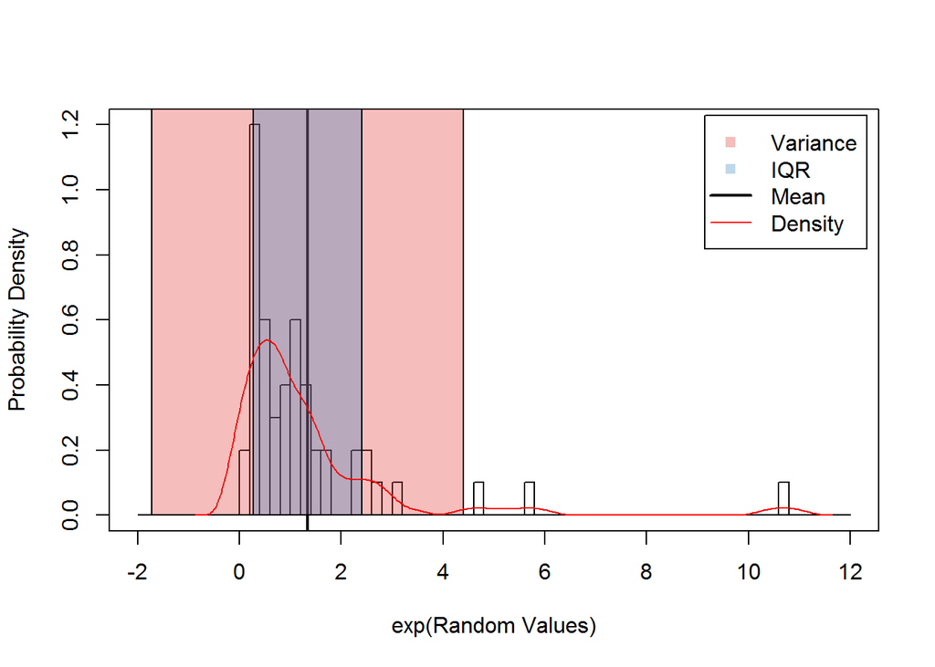

```r
expdata <- exp(data) # exponential
xbar <- mean(expdata) # calculate the mean
variance <- (sum((expdata-xbar)^2))/(length(expdata)-1) # calculate the variance
IQR <- boxplot(expdata,plot=F)$stats[4,]-boxplot(expdata,plot=F)$stats[2,] # find the IQR
spread$variance[5] <- variance;spread$IQR[5] <- IQR

hist(expdata,breaks=seq(-2,12,0.2),freq=F,ann=F)
box()
abline(v=xbar,lwd=2)
title(ylab='Probability Density',xlab = 'exp(Random Values)')
rect(xbar-variance,-0,xbar+variance,1.3,col='#de2d2650',density=-100)
rect(xbar-IQR,0,xbar+IQR,1.3,col='#3182bd50')

d <- density(expdata, adjust=1, kernel='biweight')
lines(d$x,d$y,col=2)
legend('topright',c('Variance','IQR','Mean','Density'),pch=c(15,15,NA,NA),lty=c(NA,NA,1,1),col=c('#de2d2650','#3182bd50',1,2),lwd=c(NA,NA,2,1),inset=0.015)
```

Taking the exponent of the data results in a positive skewness, a much higher variance of 3.063, and a slightly smaller IQR of 1.069.

### Summary:

Variance and IQR for each change in the data set was recorded to a data.frame. The **difference** in variance and IQR from the original distribution is summarized in the table below.

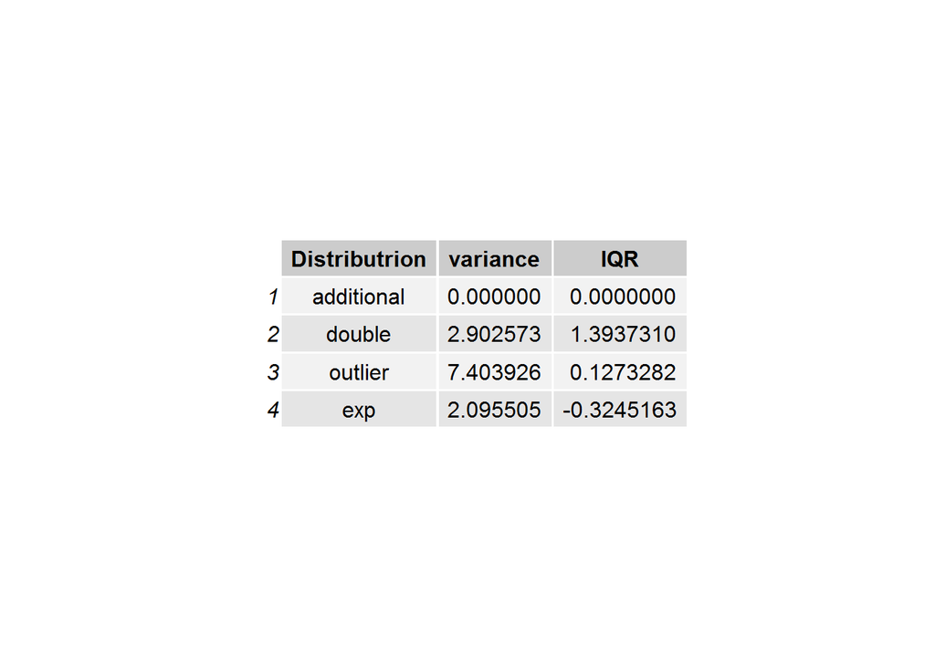

```r
temp <- data.matrix(spread) #creating a matix from the data.frame
temp <- temp[-c(1),] #removing first row
temp <- temp[,-1] #removing first column
temp <- sweep(temp,2,temp[1,]) #substracting original value from each data
Fspread <- data.frame(Distributrion=c('additional','double','outlier','exp'),variance=temp[,1],IQR=temp[,2]) #creating new data.frame with edited data
library(gridExtra) #calling gridExtra package
grid.table(Fspread) #drawing the table using new data.frame
```

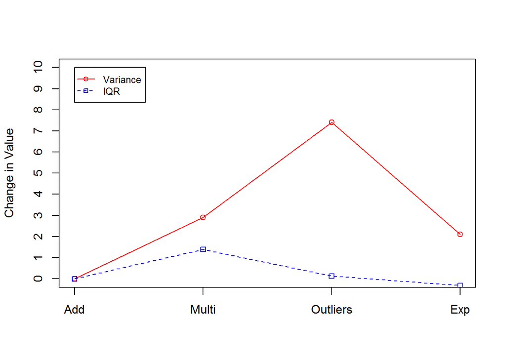

```r
plot(Fspread$variance, type="o", col="red", ylim=c(0,10), axes=FALSE, ann=FALSE) #plotting variance data
lines(Fspread$IQR, type="o", pch=22, lty=2, col="blue") #plotting IQR line on same graph
axis(1, at=1:4, lab=c("Add","Multi","Outliers","Exp"))
axis(2, at=0:10)
title(ylab="Change in Value")
legend(1, 10, c("Variance","IQR"), cex=0.8, col=c("red","blue"), pch=21:22, lty=1:2)
box()
```

**This table and the above figures clearly demonstrate that IQR is much less sensitive to extreme values than the variance.**